# week 10: final countdown

general linear madness

```r
library(tidyverse)
library(psych)
library(cowplot)
library(patchwork)
library(here)
library(brms)
library(tidybayes)
library(bayesplot)
library(rstan) # new package!
```

## thinking

Today’s class is less of a coherent topic and more of a plea to think about your data. Complex statistics are never a substitute for understanding the relationships between your constructs and drawing out the causal model.

It’s quite easy to learn about a model or technique and look for a reason to throw it at data. (I’m guilty of that. I’m probably doing that right now.) A problem with that approach is that we typically start with the model or framework and bend the data to fit that, or at least, start by assuming the assumptions of the model.

But the best models are the ones that come from the question and theory. We should start with the assumptions of our questions and theory, then find a model that fits with those.

McElreath provides several examples in this lecture/chapter about how to start from the theory and work towards a model that actually makes sense, instead of throwing a standard model at a problem. Along the way, he uses Stan code, so it’s as good a time as any to look at that.

## hidden minds

Recall the developmental psychology experiment from the lecture. There are 629 children in this dataset between the ages of 4 and 14. The outcome `y` here takes the values 1, 2, and 3. It indicates which of the three options were chosen, where 1 indicates the unchosen color, 2 indicates the majority demonstrated color, and 3 indicates the minority demonstrated color.

```r
data(Boxes, package = "rethinking")
d <- Boxes
rm(Boxes)

rethinking::precis(d)
```

```
                    mean        sd 5.5% 94.5%      histogram
y              2.1208267 0.7279860    1     3     ▃▁▁▁▇▁▁▁▁▅
gender         1.5055644 0.5003669    1     2     ▇▁▁▁▁▁▁▁▁▇
age            8.0302067 2.4979055    5    13     ▇▃▅▃▃▃▂▂▂▁
majority_first 0.4848967 0.5001696    0     1     ▇▁▁▁▁▁▁▁▁▇
culture        3.7519873 1.9603189    1     8 ▃▂▁▇▁▂▁▂▁▂▁▁▁▁
```

```r
# wrangle
d %>%
  mutate(color = factor(y,
                        levels = 1:3,
                        labels = c("unchosen", "majority", "minority"))) %>%
  mutate(y = str_c(y, " (", color, ")")) %>%
  count(y) %>%
  mutate(percent = (100 * n / sum(n))) %>%
  mutate(label = str_c(round(percent, digits = 1), "%")) %>%

  # plot
  ggplot(aes(y = y)) +
  geom_col(aes(x = n)) +
  geom_text(aes(x = n + 4, label = label), hjust = 0) +
  scale_x_continuous(expression(italic(n)), expand = expansion(mult = c(0, 0.1))) +
  labs(title = "The criterion variable y indexes three kinds of color choices",
       subtitle = "Children tended to prefer the 'majority' color.",
       y = NULL) +
  theme(axis.text.y = element_text(hjust = 0),
        axis.ticks.y = element_blank())
```

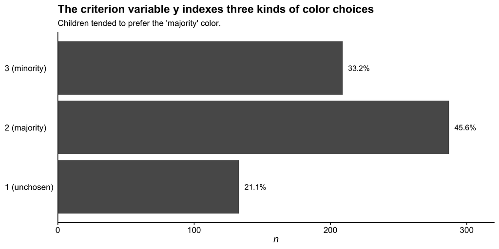

### a generative model

Consider a group of children in which half of them choose at random and the other half follow the majority. If we simulate choices for these children, we can figure out how often we might see the “2” choice, the one that indicates the majority color.

```r
set.seed(5)
N <- 30 # number of children

# half are random: sample from 1,2,3 at random for each
y1 <- sample( 1:3 , size=N/2 , replace=TRUE )

# half follow majority
y2 <- rep( 2 , N/2 )

# combine and shuffle y1 and y2
y <- sample( c(y1,y2) )

# count the 2s
sum(y==2)/N
```

```
[1] 0.6333333
```

About two-thirds of the choices are for the majority color, but only half the children are actually following the majority.

We’ll consider 5 different strategies children might use.

1. Follow the **Majority**: Copy the majority demonstrated color.
2. Follow the **Minority**: Copy the minority demonstrated color.
3. **Maverick**: Choose the color that no demonstrator chose.
4. **Random**: Choose a color at random, ignoring the demonstrators.
5. Follow **First**: Copy the color that was demonstrated first. This was either the majority color (when `majority_first` equals 1) or the minority color (when 0).

An important step here is enumerating the likelihood of each choice (1, 2, 3) for each strategy.

| Strategy | Choice 1 | Choice 2 | Choice 3 |
| --- | --- | --- | --- |
| Majority | 0 | 1 | 0 |
| Minority | 0 | 0 | 1 |
| Maverick | 1 | 0 | 0 |
| Random | 1/3 | 1/3 | 1/3 |
| Follow First | 0* | 1 or 0** | 0 or 1** |

**Notes:**

- *Follow First strategy for Choice 1: Always 0 (never chooses option 1)
- **Follow First strategy varies based on `majority_first[i]`:
  - If `majority_first[i] == 1`: Choice 2 = 1, Choice 3 = 0
  - If `majority_first[i] != 1`: Choice 2 = 0, Choice 3 = 1

We can’t directly measure each child’s strategy. It is an unobserved variable. But each strategy has a specific probability of producing each choice. We can use that fact to compute the probability of each choice, given parameters which specify the probability of each strategy. Then we let Bayes loose and get the posterior distribution of each strategy back. Before we can let Bayes loose, we’ll need to enumerate the parameters, assign priors to each, and also figure out some technical issues for coding.

we can’t directly measure each child’s strategy. It is an unobserved variable. But each strategy has a specific probability of producing each choice. We can use that fact to compute the probability of each choice, given parameters which specify the probability of each strategy. Then we let Bayes loose and get the posterior distribution of each strategy back. Before we can let Bayes loose, we’ll need to enumerate the parameters, assign priors to each, and also figure out some technical issues for coding. We’ve used these before when studying categorical outcomes.

$$p \sim \text{Dirichlet}([4,4,4,4,4])$$

```r
library(gtools)  # for rdirichlet function
set.seed(123)

# Draw samples from both distributions
samples_high <- rdirichlet(30, c(4,4,4,4,4))
samples_low <- rdirichlet(30, c(2,2,2,2,2))

# Convert to data frames and add identifiers
df_high <- data.frame(samples_high) %>%
  mutate(sample_id = 1:30,
         distribution = "Dirichlet([4,4,4,4,4])") %>%
  setNames(c(paste0("X", 1:5), "sample_id", "distribution"))

df_low <- data.frame(samples_low) %>%
  mutate(sample_id = 1:30,
         distribution = "Dirichlet([2,2,2,2,2])") %>%
  setNames(c(paste0("X", 1:5), "sample_id", "distribution"))

# Combine data frames
df_combined <- rbind(df_high, df_low)

# Reshape to long format for plotting
df_long <- df_combined %>%
  pivot_longer(cols = X1:X5,
               names_to = "component",
               values_to = "probability") %>%
  mutate(component = as.numeric(gsub("X", "", component)))

# Create the plot
ggplot(df_long, aes(x = component, y = probability, group = sample_id)) +
  geom_line(alpha = 0.6, color = "steelblue") +
  geom_hline(yintercept = 0.2, linetype = "dashed", color = "red", alpha = 0.7) +
  facet_wrap(~ distribution, ncol = 2) +
  labs(title = "Comparison of Dirichlet Distribution Samples",
       subtitle = "30 samples from each distribution (red line shows uniform expectation)",
       x = "Component",
       y = "Probability") +
  scale_x_continuous(breaks = 1:5) +
  theme_minimal() +
  theme(panel.grid.minor = element_blank(),
        strip.text = element_text(size = 12, face = "bold"))
```

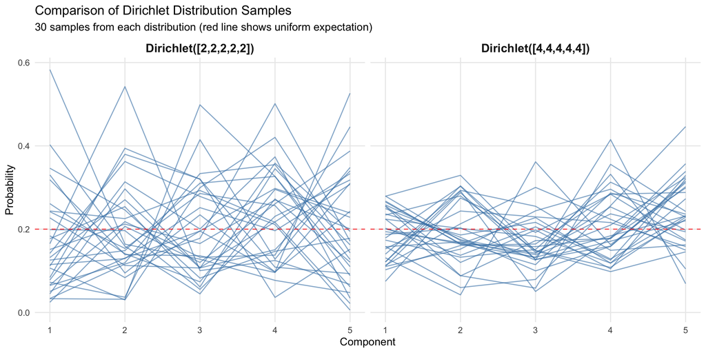

Great, now we need to express the likelihood. For each observed choice $y_i$, each strategy $s$ implies a probability of seeing $y_i$.

$$\text{Pr}(y_i) = \sum_{s=1}^5 p_s\text{Pr}(y_i|s)$$

Read this as the probability of $y_i$ is the weighted average of the probabilities of $y_i$ conditional on each strategy $s$.This expression is a mixture, as in earlier chapters. Sometimes you’ll read that this marginalizes out the unknown strategy. This just means averaging over the strategies, using some probability of each to get the weight of each in the average. Above, the values in $p$ provide these weights.

### mathematical model

We can put all these pieces together in a (very simple) statistical model.

$$\begin{align*}
y_i &\sim \text{Categorical}(\theta) \\
\theta &= \sum_{s=1}^5 p_s\text{Pr}(y_i|s) \\
p \sim \text{Dirichlet}([4,4,4,4,4])
\end{align*}$$

On to the Stan code…

### stan by me, when you’re not strong

First, we list the data. Recall our outcome is `y` and we’re using the variable `majority_first` to indicate the order in which children saw the two groups of peers. `N` is not part of our data, but Stan uses this to index sample size.

```latex
data{
    int N;
    array[N] int y;
    array[N] int majority_first;
}
```

Next, we list our `parameters`. In this case, we’re trying to estimate the proportion of children who use each strategy:

```latex
parameters{
    simplex[5] p;
}
```

Now for the model. This bit is chunky.

```latex
model{
    vector[5] phi;

    // prior
    p ~ dirichlet( rep_vector(4,5) );

    // probability of data
    for ( i in 1:N ) {
        if ( y[i]==2 ) phi[1]=1; else phi[1]=0; // majority
        if ( y[i]==3 ) phi[2]=1; else phi[2]=0; // minority
        if ( y[i]==1 ) phi[3]=1; else phi[3]=0; // maverick
        phi[4]=1.0/3.0;                         // random
        if ( majority_first[i]==1 )             // follow first
            if ( y[i]==2 ) phi[5]=1; else phi[5]=0;
        else
            if ( y[i]==3 ) phi[5]=1; else phi[5]=0;

        // compute log( p_s * Pr(y_i|s )
        for ( j in 1:5 ) phi[j] = log(p[j]) + log(phi[j]);
        // compute average log-probability of y_i
        target += log_sum_exp( phi );
    }
}
```

To add run this code in R, add all of this to a character string. The function `cat()` allows you to see the string with the formatting (line breaks, etc).

```r
boxes_stan = "
  data{
    int N;
    array[N] int y;
    array[N] int majority_first;
    }
  parameters{
    simplex[5] p;
    }
  model{
    vector[5] phi;

    // prior
    p ~ dirichlet( rep_vector(4,5) );

    // probability of data
    for ( i in 1:N ) {
        if ( y[i]==2 ) phi[1]=1; else phi[1]=0; // majority
        if ( y[i]==3 ) phi[2]=1; else phi[2]=0; // minority
        if ( y[i]==1 ) phi[3]=1; else phi[3]=0; // maverick
        phi[4]=1.0/3.0;                         // random
        if ( majority_first[i]==1 )             // follow first
            if ( y[i]==2 ) phi[5]=1; else phi[5]=0;
        else
            if ( y[i]==3 ) phi[5]=1; else phi[5]=0;

        // compute log( p_s * Pr(y_i|s )
        for ( j in 1:5 ) phi[j] = log(p[j]) + log(phi[j]);
        // compute average log-probability of y_i
        target += log_sum_exp( phi );
    }
  }
"
cat(boxes_stan)
```

```
  data{
    int N;
    array[N] int y;
    array[N] int majority_first;
    }
  parameters{
    simplex[5] p;
    }
  model{
    vector[5] phi;

    // prior
    p ~ dirichlet( rep_vector(4,5) );

    // probability of data
    for ( i in 1:N ) {
        if ( y[i]==2 ) phi[1]=1; else phi[1]=0; // majority
        if ( y[i]==3 ) phi[2]=1; else phi[2]=0; // minority
        if ( y[i]==1 ) phi[3]=1; else phi[3]=0; // maverick
        phi[4]=1.0/3.0;                         // random
        if ( majority_first[i]==1 )             // follow first
            if ( y[i]==2 ) phi[5]=1; else phi[5]=0;
        else
            if ( y[i]==3 ) phi[5]=1; else phi[5]=0;

        // compute log( p_s * Pr(y_i|s )
        for ( j in 1:5 ) phi[j] = log(p[j]) + log(phi[j]);
        // compute average log-probability of y_i
        target += log_sum_exp( phi );
    }
  }
```

Let’s integrate this with `brms` so we can make use of some of the helper functions.

First, we’ll create an empty brmsfit object.

```r
# We need to create a dummy model that has similar structure to what we want
m1 <- brm(
  y ~ 1,  # Simple intercept model as placeholder
  data = d,
  family = categorical(),  # Since you have categorical outcomes
  chains = 0,  # Don't actually fit
  silent = 2,
  refresh = 0
)
```

Next, we prepare the data for Stan:

```r
library(rstan)
stan_data <- list(
  N = nrow(d),
  y = d$y,
  majority_first = d$majority_first
)
```

The function `stan_model` will convert our character string to something that Stan can recognize.

```r
# Compile the custom Stan model
custom_stan_model <- stan_model(model_code = boxes_stan)

# Fit the custom model
custom_fit <- sampling(
  custom_stan_model,
  data = stan_data,
  chains = 4, iter = 2000, warmup = 1000, cores = 4
)
```

```r
# Replace the fit slot in the brmsfit object
m1$fit <- custom_fit

# Also update the model slot to contain the Stan code
m1$model <- boxes_stan

# Update the data
m1$data <- d
```

And that’s it! You can now use (some) of the usual functions to evaluate your model.

Note that some functions will work, but others will not.

```r
posterior_summary(m1)
```

```
         Estimate  Est.Error          Q2.5        Q97.5
p[1]    0.2571846 0.03657030    0.18430188    0.3266894
p[2]    0.1379903 0.03226541    0.07350504    0.1988042
p[3]    0.1474092 0.03055084    0.08339295    0.2033196
p[4]    0.1981705 0.08014053    0.06273866    0.3693370
p[5]    0.2592454 0.03187899    0.19698956    0.3205356
lp__ -667.1548403 1.50296677 -670.99662701 -665.3105596
```

```r
m1 # doesn't work
```

```r
mcmc_rank_overlay(m1)
```

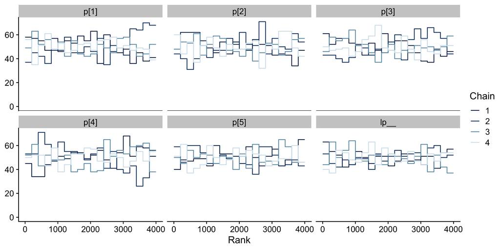

```r
gather_draws(m1, p[strategy]) |>
  ggplot( aes(x=.value, fill=as.factor(strategy) )) +
  stat_halfeye(alpha=.5)
```

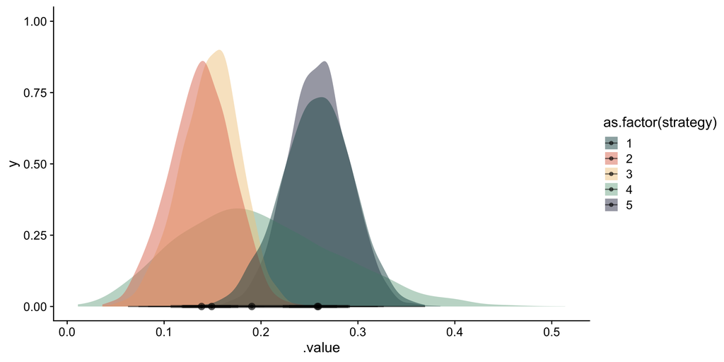